# How many colours are in each national flag?

The flag of Bosnia and Herzegovina has blue, yellow, and white — matching Gemini’s list. The blue is a medium to dark blue (sometimes called ‘UN blue’), the yellow is a golden-yellow triangle, and the stars are white. No colours are missing or invented.

agree

3

The flag of Bosnia and Herzegovina correctly features three main colours: blue, yellow, and white.

[figure not shown]

Botswana

3

light blue, black, white

agree

3

The flag of Botswana consists of a light blue field with a black horizontal stripe in the center, bordered above and below by thin white stripes. Gemini correctly identified the three colours: light blue, black, and white.

agree

3

Gemini correctly identified all three colours present on the flag of Botswana: light blue, black, and white.

[figure not shown]

Brazil

4

green, yellow, blue, white

agree

4

The flag of Brazil contains green, yellow, blue (in the globe), and white (in the band and stars). Gemini’s list matches exactly — no colours are missing or invented. The blue is a deep navy shade, which is acceptable as ‘blue’ under near-synonym tolerance.

agree

4

The flag of Brazil consists of four main colours: green, yellow, blue, and white (with green text on the white band, which uses the same shade of green as the background).

[figure not shown]

Brunei

4

yellow, white, black, red

agree

4

The flag of Brunei features a yellow field with diagonal black and white stripes, and a red emblem in the center. The emblem contains red and some gold/yellow details (crown, wings, etc.), but no distinct separate 'gold' colour — it’s part of the yellow field or shaded red. Gemini listed yellow, white, black, red — all of which are visibly present. No extra colours are invented, and no major colour is missing. 'Gold' is sometimes used interchangeably with 'yellow' in flag descriptions, so this is acceptable.

agree

4

Gemini correctly identified all four colours of the flag of Brunei: yellow, white, black, and red.

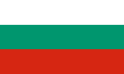

Bulgaria

3

white, green, red

3

white, green, red

agree

3

The flag of Bulgaria consists of three equal horizontal bands of white, green, and red, matching Gemini's list.

[figure not shown]

Burkina Faso

3

red, green, yellow

agree

3

The flag of Burkina Faso consists of two horizontal bands — red on top and green on bottom — with a yellow five-pointed star centered at the division. Gemini correctly identified all three colours: red, green, and yellow. No extra or missing colours are present.

agree

3

The flag of Burkina Faso consists of two equal horizontal stripes of red and green with a yellow star in the center. Gemini correctly identified all three colours.

[figure not shown]

Burundi

4

white, red, green, gold

mostly_agree

4

disagree

3

gold

The flag of Burundi contains only three colours: white, red, and green. The three stars in the center are red outlined in green; there is no gold on the flag.

[figure not shown]

Cambodia

3

blue, red, white

agree

3

The flag of Cambodia consists of three horizontal stripes: blue on top and bottom, and red in the middle. In the center of the red stripe is a white depiction of Angkor Wat. Gemini correctly identified all three colours present: blue, red, and white. No extra or missing colours are reported.

mostly_agree

4

black

The main colours are red, blue, and white, but black is also present in the fine outline details of the Angkor Wat temple emblem.

[figure not shown]

Cameroon

3

green, red, yellow

agree

3

The flag of Cameroon has three vertical stripes: green on the left, red in the center, and yellow on the right. A yellow five-pointed star is centered on the red stripe. Gemini correctly identified all three colours present — green, red, and yellow — with no extra or missing colours.

agree

3

The flag of Cameroon consists of three distinct colors: green, red, and yellow, with yellow used for both the right vertical stripe and the central star.

[figure not shown]

Canada

2

red, white

agree

2

The Canadian flag shown consists of two vertical red bars on the sides and a white square in the center with a red maple leaf. Gemini correctly identifies the only two colours present: red and white. No other colours are visible or implied.

agree

2

Gemini correctly identified the two colors on the flag of Canada: red and white.

[figure not shown]

Cape Verde

4

blue, white, red, yellow

agree

4

The flag of Cape Verde has blue (field), white (stripes), red (stripe), and yellow (stars). Gemini’s list matches exactly.

agree

4

Gemini correctly identified all four colours present on the flag of Cape Verde: blue, white, red, and yellow.

[figure not shown]

Central African Republic

5

blue, white, green, yellow, red

agree

5

The flag has blue, white, green, yellow, and red — exactly as stated. The vertical red stripe and the yellow star are clearly visible, and all five colours are present.

agree

5

Gemini correctly identified all five colours present on the flag of the Central African Republic: blue, white, green, yellow, and red.

[figure not shown]

Chad

3

blue, yellow, red

mostly_agree

3

The flag has three vertical stripes: blue (left), yellow (middle), red (right). Gemini correctly identified all three colours. Although the blue is technically navy blue, it is acceptable to call it "blue" as a near-synonym. No colours are missing or invented.

agree

3

The flag of Chad is a vertical tricolour of blue, yellow, and red. The colour list and count are completely accurate.

[figure not shown]

Chile

3

white, red, blue

agree

3

The flag of Chile consists of two horizontal bands: white on top and red on bottom, with a blue square in the canton containing a white star. The colours present are indeed white, red, and blue — matching Gemini’s list exactly.

agree

3

Gemini correctly identified all three colours of the Chilean flag: white, red, and blue.

[figure not shown]

China

2

red, yellow

agree

2

The flag of China is red with five yellow stars. Gemini correctly identified the two colours: red and yellow. No colours are missing or incorrectly added.

agree

2

Gemini correctly identified both colours present on the flag of China: red and yellow.

[figure not shown]

Colombia

3

yellow, blue, red

agree

3

The flag of Colombia consists of three horizontal stripes: yellow (top, double-width), blue (middle), and red (bottom). Gemini correctly identified all three colors: yellow, blue, and red. No extra or missing colors are present. The shades are standard for the flag — golden yellow, navy blue, and crimson red — which fall within acceptable synonyms (e.g., ‘blue’ for navy blue).

agree

3

The flag of Colombia consists of three horizontal stripes of yellow, blue, and red.

[figure not shown]

Comoros

5

yellow, white, green, red, blue

agree

5

agree

5

The flag of Comoros features four horizontal stripes (yellow, white, red, blue) and a green chevron containing a white crescent and four stars, matching Gemini's list of 5 colours.

[figure not shown]

Congo, Democratic Republic of the

3

blue, red, yellow

agree

3

The flag has blue as the main field, red for the diagonal band, and yellow for the star and the borders of the red band. Gemini correctly identified all three colours.

agree

3

The flag features a light blue field with a red diagonal stripe bordered in yellow, plus a yellow star in the canton. Gemini correctly identified all three colours.

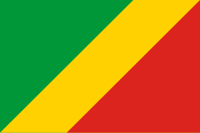

Congo, Republic of the

3

green, yellow, red

agree

3

The flag of the Republic of the Congo clearly displays three colors: green on the upper left, red on the lower right, and a yellow diagonal band separating them. Gemini’s list — green, yellow, red — accurately reflects these three colors without adding or omitting any.

agree

3

Gemini correctly identified the three diagonal colours (green, yellow, and red) of the Republic of the Congo's flag.

[figure not shown]

Costa Rica

3

white, red, blue

agree

3

The flag of Costa Rica consists of five horizontal stripes: blue, white, red, white, and blue. The colours present are indeed blue, white, and red — no other hues appear. Gemini correctly identified all three distinct colours. Although the flag has five stripes, they repeat only these three colours.

agree

3

Gemini correctly identified the three colours (blue, white, and red) present on the civil flag of Costa Rica.

[figure not shown]

Croatia

5

red, white, blue, yellow, light blue

mostly_agree

4

light blue

mostly_agree

6

black

Gemini correctly identified all major colours on the flag and coat of arms (red, white, blue, light blue, and yellow), but omitted the small black detail on the marten in the Slavonian shield.

[figure not shown]

Cuba

3

blue, white, red

agree

3

The flag of Cuba consists of five horizontal stripes (three blue and two white) and a red equilateral triangle at the hoist with a white five-pointed star. The colours present are blue, white, and red — exactly as Gemini listed. No extra or missing colours are present.

agree

3

Gemini correctly identified the three colours present on the flag of Cuba: blue, white, and red.

[figure not shown]

Cyprus

3

white, orange, green

agree

3

The flag of Cyprus has a white field, an orange (actually copper-orange) map of the island, and two green olive branches beneath. Gemini correctly identified all three colours: white, orange, and green. Although 'orange' is often described as 'copper' in official sources, it’s visually close enough to accept as orange. No extra or missing colours.

agree

3

Gemini correctly identified the 3 colours on the flag of Cyprus: the white background, the copper/orange map silhouette, and the green olive branches.

[figure not shown]

Czech Republic

3

white, red, blue

agree

3

The flag of the Czech Republic has three colours: white (top stripe), red (bottom stripe), and blue (in the triangle on the hoist side). Gemini correctly listed all three. The blue is dark/royal blue, which is acceptable as 'blue' in this context.

agree

3

The flag of the Czech Republic consists of three distinct colours: white, red, and blue.

[figure not shown]

Denmark

2

red, white

agree

2

The flag of Denmark consists of a red field with a white Scandinavian cross that extends to the edges of the flag. Gemini correctly identified the two colors: red and white. No other colors are present, and no colors are missing.

agree

2

Gemini correctly identified the two colours of the Danish flag, which consists of a white Nordic cross on a red field.

[figure not shown]

Djibouti

4

light blue, white, green, red

agree

4

The flag of Djibouti has three main fields: light blue (top), green (bottom), and a white isosceles triangle on the hoist side. Inside the white triangle is a red five-pointed star. Gemini listed four colours: light blue, white, green, and red — which exactly matches the visible colours in the image. No extra or missing colours are present.

agree

4

Gemini correctly identified all four colours of the flag of Djibouti: light blue, green, white, and red.

[figure not shown]

Dominica

7

green, yellow, red, black, white, purple, brown

disagree

5

purple, brown

agree

7

Gemini correctly identified all 7 colours on the flag of Dominica: green (field, stars, parrot back), yellow, black, and white (stripes), red (central disc), purple (parrot head and chest), and brown (the branch).

[figure not shown]

Dominican Republic

6

blue, white, red, green, gold, brown

disagree

3

green, gold, brown

agree

6

The flag features blue, white, and red in its main field, with green, gold, and brown visible in the central coat of arms details.

[figure not shown]

Ecuador

8

yellow, blue, red, brown, white, green, grey, black

mostly_agree

8

The Ecuadorian flag has three horizontal stripes: yellow (top, double width), blue (middle), and red (bottom). The national coat of arms in the center includes additional colors: white (in the sky and clouds), green (in the landscape), brown (in the mountain/earth tones), black (eagle’s wings), grey (possibly in mountain shading or metallic elements), and gold/yellow (in the wreath and sunburst — treated as same as yellow). So while some shades are subtle, all 8 colors listed by Gemini can be reasonably identified. Grey may be borderline if interpreted strictly, but it’s plausible in the emblem’s shading.

agree

8

The colour list accurately identifies both the main tricolour (yellow, blue, red) and the detailed colours within the coat of arms (brown, white, green, grey, black).

[figure not shown]

Egypt

4

red, white, black, yellow

agree

4

The flag of Egypt has three horizontal stripes: red (top), white (middle), and black (bottom). In the center of the white stripe is the national emblem, the Eagle of Saladin, which is gold/yellow. Gemini correctly identified all four colours present: red, white, black, and yellow (gold).

agree

4

The flag features red, white, and black horizontal stripes with a gold/yellow Eagle of Saladin in the center. Gemini correctly listed all four colours.

[figure not shown]

El Salvador

7

blue, white, yellow, green, red, brown, black

mostly_agree

6

brown

The flag of El Salvador has only three main colours: blue, white, and the colours within the coat of arms. The coat of arms includes green (for laurel branches), yellow/gold (for the text and some details), red (for the Phrygian cap), and black (for outlines or lettering). Brown is not present. Gemini listed 7 colours including brown and black — but brown is incorrect, and black is borderline since it’s used minimally for outlines. Strictly speaking, brown should not be included.

mostly_agree

6

brown, black

The flag of El Salvador prominently features blue, white, yellow/gold, green, and red in its coat of arms. Brown and black are not distinct colors on the official flag, though Gemini correctly identified the major colors present.

[figure not shown]

Equatorial Guinea

6

green, white, red, blue, yellow, brown

mostly_agree

5

brown

agree

6

The flag features green, white, and red horizontal stripes with a blue triangle at the hoist. The coat of arms in the centre adds yellow for the six stars and brown for the tree trunk.

[figure not shown]

Eritrea

4

red, green, blue, yellow

agree

4

The flag of Eritrea contains red, green, blue, and yellow — exactly as Gemini listed. The red forms the large triangle, green is at the top, blue at the bottom, and the emblem (wreath with olive branch) is yellow/gold. No extra or missing colours; near-synonym ‘gold’ vs ‘yellow’ is acceptable.

agree

4

Gemini correctly identified all four colours present on the flag of Eritrea: red, green, blue, and yellow.

[figure not shown]

Estonia

3

blue, black, white

agree

3

The flag of Estonia consists of three equal horizontal bands: blue on top, black in the middle, and white at the bottom. Gemini correctly identified all three colours without adding or omitting any.

agree

3

Gemini correctly identified all three colours (blue, black, and white) present on the flag of Estonia.

[figure not shown]

Eswatini

6

red, blue, yellow, black, white, grey

disagree

5

grey

The flag of Eswatini contains red, blue, yellow, black, and white. There is no grey in the flag — the central shield has black and white sections, but no grey. Gemini incorrectly added grey as a sixth colour.

mostly_agree

5

grey

The flag of Eswatini features five primary colours: red, blue, yellow, black, and white. Grey is not present on this flag.

[figure not shown]

Ethiopia

4

green, yellow, red, blue

disagree

3

blue

agree

4

The flag contains four distinct colours: green, yellow, red, and blue. Gemini's list is completely accurate.

[figure not shown]

Fiji

7

light blue, red, white, dark blue, yellow, green, brown

disagree

6

black

brown

The Fiji flag contains light blue (field), red, white, and dark blue (in the Union Jack), plus yellow (on the lion and sugarcane) and green (on the palm trees and banana leaf). Brown is not present — the shield’s outline and details are black or dark grey, not brown. Gemini incorrectly added brown and omitted black, which appears in the shield’s border and emblems. Also, ‘green’ is correct but only appears as small accents; it’s not a dominant field color. The count of 7 is wrong — there are 6 actual colors: light blue, red, white, dark blue, yellow, green. Brown is an error.

agree

7

Gemini correctly identified all 7 main colours present on the flag of Fiji, including the field, the Union Jack, and the coat of arms details.

[figure not shown]

Finland

2

white, blue

agree

2

agree

2

The flag of Finland consists of a blue Nordic cross on a white background, matching Gemini's list.

[figure not shown]

France

3

blue, white, red

agree

3

The flag of France consists of three vertical stripes: blue (on the hoist side), white (in the middle), and red (on the fly side). Gemini correctly identified all three colours. The blue is a deep navy, which is commonly referred to as 'blue' in general descriptions, and the red is a bright crimson — both are accurately captured by the terms used. No extra or missing colours.

agree

3

The flag of France clearly consists of three vertical bands of dark blue, white, and red.

[figure not shown]

Gabon

3

green, yellow, blue

agree

3

The flag of Gabon consists of three horizontal stripes: green on top, yellow in the middle, and blue at the bottom. Gemini correctly identified all three colours: green, yellow, and blue. No extra or missing colours are present.

agree

3

The flag of Gabon is a horizontal tricolour of green, yellow, and blue. Gemini's list is completely accurate.

[figure not shown]

Gambia, The

4

red, blue, green, white

agree

4

The flag of The Gambia has three horizontal bands: red (top), blue (middle), green (bottom), separated by two thin white stripes. So the four colours are red, blue, green, and white — matching Gemini’s list exactly.

agree

4

The flag of The Gambia features horizontal stripes of red, white, blue, white, and green, making four distinct colours in total.

[figure not shown]

Georgia

2

white, red

agree

2

The flag of Georgia consists of a white field with a large red cross and four smaller red crosses in each quadrant. Only white and red are present — matching Gemini’s answer exactly.

agree

2

The flag of Georgia consists solely of a white background and red crosses. Gemini's color list is completely accurate.

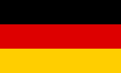

Germany

3

black, red, gold

agree

3

The flag of Germany consists of three horizontal stripes: black on top, red in the middle, and gold (often called yellow) at the bottom. Gemini correctly identified all three colors. While 'gold' is sometimes colloquially referred to as 'yellow', it is the official term used in German heraldry and constitutional descriptions — so treating 'gold' and 'yellow' as near-synonyms is appropriate here.

agree

3

The flag of Germany consists of three horizontal bands of black, red, and gold (yellow). Gemini's list is completely accurate.

[figure not shown]

Ghana

4

red, yellow, green, black

agree

4

The flag of Ghana has three horizontal stripes: red (top), yellow (middle), and green (bottom), with a black five-pointed star centered on the yellow stripe. Gemini correctly identified all four colours: red, yellow, green, and black. No colours are missing or invented.

agree

4

Gemini correctly identified all four colours present on the flag of Ghana: red, yellow, green, and black.

[figure not shown]

Greece

2

blue, white

agree

2

The flag of Greece consists only of blue and white stripes with a blue canton bearing a white cross. Gemini correctly identified the two colours present: blue and white. No other colours are visible in the flag.

agree

2

The flag of Greece consists of blue and white horizontal stripes with a white cross on a blue square in the upper hoist corner.

[figure not shown]

Grenada

3

red, yellow, green

agree

3

agree

3

The flag of Grenada consists of exactly three colours: red, yellow, and green.

[figure not shown]

Guatemala

7

light blue, white, green, brown, yellow, grey, black

disagree

5

grey, black

mostly_agree

8

red

Gemini correctly identified almost all colours on the flag and coat of arms, but missed the small red accent on the chest of the quetzal bird.

[figure not shown]

Guinea

3

red, yellow, green

agree

3

The flag of Guinea consists of three vertical stripes: red on the hoist side, yellow in the center, and green on the fly side. Gemini correctly identified all three colours without adding or omitting any.

agree

3

The flag of Guinea is a vertical tricolour of red, yellow, and green. Gemini's answer is completely accurate.

[figure not shown]

Guinea-Bissau

4

yellow, red, green, black

agree

4

The flag of Guinea-Bissau has three horizontal bands: yellow (top), green (bottom), and a red vertical band at the hoist with a black star. So the colours present are yellow, red, green, and black — exactly matching Gemini’s list.

agree

4

The flag of Guinea-Bissau features a vertical red stripe at the hoist with a black star, and two horizontal stripes of yellow and green on the fly side. Gemini correctly identified all four colours.

[figure not shown]

Guyana

5

green, yellow, red, white, black

agree

5

The flag of Guyana contains five distinct colours: green (background), yellow (central arrowhead), red (inner triangle), white (border around yellow), and black (thin border around red). Gemini’s list matches exactly.

agree

5

Gemini correctly identified all five colours present on the flag of Guyana: green, yellow, red, white, and black.

[figure not shown]

Haiti

6

blue, red, white, green, gold, brown

agree

6

The flag of Haiti has two main horizontal bands: blue (top) and red (bottom). The central coat of arms includes white (background), green (palm tree and wreath), gold/yellow (crown, cannons, flags, ribbon text), and brown (tree trunk). Gemini listed 6 colours: blue, red, white, green, gold, brown — which matches the visible colours. Although 'gold' and 'yellow' are sometimes used interchangeably, here 'gold' is acceptable for the metallic yellow elements. No extra or missing colours are present.

agree

6

Gemini correctly identified the six main colours present on the flag of Haiti and its coat of arms.

[figure not shown]

Honduras

2

blue, white

agree

2

The flag of Honduras consists of three horizontal stripes: two blue outer stripes and one white central stripe. The five stars in the center are also blue, matching the outer stripes. Gemini correctly identified the two distinct colors as blue and white — no other colors are present. This matches the image exactly.

agree

2

The flag of Honduras consists of two blue stripes, a middle white stripe, and five blue stars in the center.

[figure not shown]

Hungary

3

red, white, green

agree

3

The flag of Hungary consists of three equal horizontal bands: red on top, white in the middle, and green at the bottom. Gemini correctly identified all three colors without adding or omitting any.

agree

3

Gemini correctly identified all three colours of the Hungarian flag (red, white, and green).

[figure not shown]

Iceland

3

blue, white, red

agree

3

The flag of Iceland clearly displays three colors: a deep blue field, a white cross, and a red cross within the white one. Gemini’s list — blue, white, red — correctly identifies all three colors present in the flag. No colors are missing or incorrectly added.

agree

3

Gemini correctly identified the three colours present on the flag of Iceland: blue, white, and red.

[figure not shown]

India

4

saffron, white, green, navy blue

mostly_agree

4

The flag has saffron (top stripe), white (middle stripe), green (bottom stripe), and navy blue (in the Ashoka Chakra). Gemini correctly identified all four colours. Note: 'navy blue' is acceptable as a synonym for the dark blue used in the Ashoka Chakra; some might call it simply 'blue', but 'navy blue' is a reasonable descriptor.

agree

4

Gemini accurately identified all 4 colours on the Indian flag: saffron, white, green, and navy blue for the Ashoka Chakra.

[figure not shown]

Indonesia

2

red, white

agree

2

The flag of Indonesia consists of two equal horizontal bands: red on top and white on the bottom. Gemini correctly identified the two colours as red and white, with no extra or missing colours.

agree

2

The flag of Indonesia consists of two horizontal bands of red and white, exactly as described.

[figure not shown]

Iran

3

white, green, red

agree

3

The flag of Iran consists of three horizontal stripes: green (top), white (middle), and red (bottom). The emblem in the center and the Kufic script along the edges are also red and green, respectively — but these are not additional primary colours. Gemini correctly identified the three main colours as white, green, and red. No colours are missing or invented.

agree

3

Gemini correctly identified the three colours present on the flag of Iran: green, white, and red.

[figure not shown]

Iraq

4

red, white, black, green

agree

4

The flag of Iraq consists of three horizontal stripes: red (top), white (middle), and black (bottom). In the center of the white stripe is green Arabic script (“الله أكبر”). Therefore, the four colours present are indeed red, white, black, and green. Gemini’s answer is accurate.

agree

4

Gemini correctly identified all four colours on the flag of Iraq: red, white, black, and green for the Arabic script.

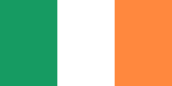

Ireland

3

green, white, orange

agree

3

The flag of Ireland consists of three vertical stripes: green, white, and orange. Gemini correctly identified all three colours with no additions or omissions.

agree

3

Gemini correctly identified the three colours of the Irish tricolour: green, white, and orange.

[figure not shown]

Israel

2

white, blue

agree

2

The flag of Israel consists of two horizontal blue stripes and a blue Star of David on a white background. Gemini correctly identified the two colours: white and blue. No other colours are present.

agree

2

Gemini correctly identified the two colours present on the flag of Israel, which are white and blue.

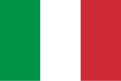

Italy

3

green, white, red

agree

3

The flag of Italy is correctly described as having three vertical stripes: green, white, and red. Gemini’s list matches exactly.

agree

3

Gemini correctly identified the three vertical stripes of green, white, and red that make up the flag of Italy.

[figure not shown]

Ivory Coast

3

orange, white, green

agree

3

The flag of Ivory Coast is a tricolor with three equal vertical bands: orange on the hoist side, white in the center, and green on the fly side. Gemini correctly identified all three colors without adding or omitting any.

agree

3

Gemini correctly identified the three colours of the Ivory Coast flag: orange, white, and green.

[figure not shown]

Jamaica

3

green, black, yellow

agree

3

The flag of Jamaica clearly shows three colours: green, black, and yellow. Gemini’s list matches exactly. No colours are missing or invented.

agree

3

Gemini correctly identified all three colours present on the flag of Jamaica: green, black, and yellow (gold).

[figure not shown]

Japan

2

white, red

agree

2

The flag of Japan consists of a white field with a red circle at the center. Gemini correctly identified the two colours: white and red.

agree

2

Gemini correctly identified the two colours of the Japanese flag (white and red).

[figure not shown]

Jordan

5

black, white, red, green, yellow

disagree

4

yellow

The Jordanian flag consists of three horizontal stripes: black (top), white (middle), and green (bottom), with a red triangle at the hoist bearing a white seven-pointed star. The only colours present are black, white, red, and green. Yellow is not in the flag.

disagree

4

yellow

The flag of Jordan contains only four colours: black, white, green, and red. Yellow is not present on this flag.

[figure not shown]

Kazakhstan

2

blue, yellow

agree

2

The flag of Kazakhstan has a sky-blue field with a golden sun and eagle, plus a vertical ornamental pattern (koshkar-muiz) on the hoist. Gemini correctly identifies blue and yellow — though 'yellow' is technically gold in heraldic terms, it’s acceptable as a near-synonym. No other colours are present.

agree

2

The flag of Kazakhstan consists of a light blue background field with a yellow sun, eagle, and ornamental pattern along the hoist.

[figure not shown]

Kenya

5

black, red, green, white, grey

4

grey

The flag of Kenya has three horizontal stripes: black (top), red (middle), and green (bottom), separated by thin white fimbriations. The central emblem is a red shield with white details, flanked by two white spears. There is no grey in the flag — the dark areas are black, not grey. Gemini incorrectly listed 'grey' instead of correctly identifying all instances of black. Also, while 'white' is correctly included, it’s worth noting that white appears only as narrow stripes and emblem details, not as a primary field color. Overall, the list contains an extra, incorrect color (grey) and misses nothing essential — but since grey is not present, the answer is inaccurate.

disagree

4

grey

The flag of Kenya consists of four colours: black, red, green, and white. There is no grey on the flag.

[figure not shown]

Kiribati

4

red, blue, white, yellow

agree

4

The flag of Kiribati has a red upper half with a golden-yellow sun and frigatebird, and a lower half with three wavy blue and white stripes representing the ocean. Gemini correctly identifies red, blue, white, and yellow — though ‘yellow’ is technically ‘golden yellow’, this is acceptable as a near-synonym. No extra or missing colours are present.

agree

4

The flag of Kiribati features four main colours: red for the upper half, yellow for the sun and frigatebird, and alternating white and blue wavy stripes.

[figure not shown]

Kuwait

4

white, red, green, black

agree

4

The flag of Kuwait consists of three horizontal stripes (green, white, red) and a black trapezoid on the hoist side. Gemini correctly identified all four colours: white, red, green, and black. No extra or missing colours are present.

agree

4

Gemini correctly identified all four colours (green, white, red, and black) of the flag of Kuwait.

[figure not shown]

Kyrgyzstan

2

red, yellow

agree

2

The flag of Kyrgyzstan has a red field and a yellow sun emblem with 40 rays and a tunduk (yurt crown) in the center. Gemini correctly identified the two colours: red and yellow. No colours are missing or invented.

agree

2

The flag of Kyrgyzstan features a red field with a yellow sun containing a red tunduk (yurt emblem) in the center, for a total of two colours.

[figure not shown]

Laos

3

red, blue, white

agree

3

The flag of Laos consists of three horizontal stripes: red (top and bottom) and blue (middle), with a white disc in the center. Gemini correctly identified the three colours as red, blue, and white — no extra or missing colours.

agree

3

The flag of Laos consists of exactly three colours: red, blue, and white.

[figure not shown]

Latvia

2

red, white

agree

2

The flag of Latvia consists of two horizontal bands of deep red (maroon) with a white stripe in the center. Gemini correctly identified the two colours as red and white. Although the red is a specific shade (often called 'Latvian red' or maroon), it is acceptable to call it 'red' in this context. No colours are missing or invented.

mostly_agree

2

The flag consists of two colours: white and a distinct dark maroon/carmine red (often referred to as Latvian red). Calling it simply 'red' is acceptable as a general color description.

[figure not shown]

Lebanon

3

red, white, green

agree

3

The flag of Lebanon has two red horizontal stripes, a central white stripe, and a green cedar tree in the center. Gemini correctly identified red, white, and green as the three colours. No colours are missing or invented.

agree

3